# Calculation

Q 1: Begin with the median from a sample of N = 200 from the standard normal distribution. Write an R function that is the density function for the median in this sample. Note that the 100th order statistic is approximately the median, and use the order statistic formula discussed in class. Generate a plot of the function.

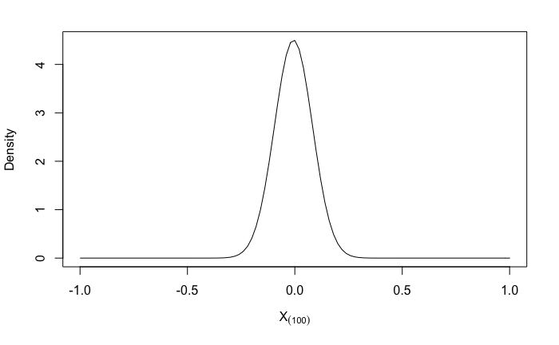

```r
dorder <- function(x) {
  k <- 100
  n <- 200
  k * choose(n, k) *
  (pnorm(x, 0, 1)) ^ (k - 1) *
  (1 - pnorm(x, 0, 1)) ^ (n - k) *
  dnorm(x, 0, 1)
}
curve(dorder(x), -1, 1, xlab = parse(text="X[(100)]"), ylab = "Density")
```

Q 2: Write an R function that is the probability function for the median in this sample. Use the order statistic formula discussed in class. Generate a plot of the function.

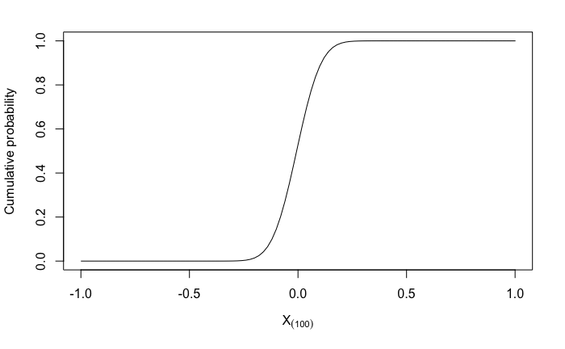

```r
porder <- function(x){
  k <- 100
  n <- 200
  pbinom(k-1, n, pnorm(x, 0,1), lower.tail = FALSE)
}
curve(porder(x), -1, 1, xlab = parse(text="X[(100)]"), ylab = "Cumulative probability")
```

Q 3: Write an R function that is the quantile function for the median in this sample. (You have several options for how to write this function.) Generate a plot of the function.

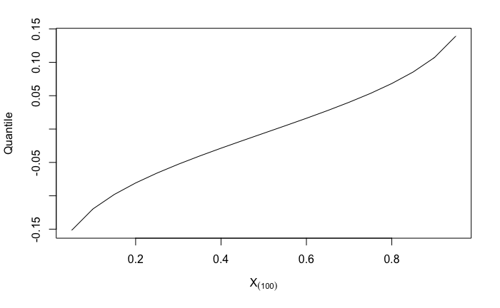

```r
qtl <- seq(0.05, 0.95, 0.05)
med_dis <- rep(NA, 19)
qorder <- function(h){
  k <- 100
  n <- 200
  for(i in seq_along(h)){
    med_dis[i] <- uniroot(function(x, p) porder(x)-p, c(-5,5), p = h[i])$root
  }
  med_dis
}
plot(qtl, qorder(qtl), type = "l", xlab = parse(text="X[(100)]"), ylab = "Quantile")
```

Q 4: Simulate the sampling distribution for the median as you did in the previous deliverable. Create a plot of the empirical CDF (ECDF). Overlay the plot of the ECDF with a plot of the CDF.

```r
N <- 200
M <- 500
dis <- rep(NA, M)   # distribution of medians of the M times of simulation
for(i in 1: M){
  dis[i] <- median(rnorm(N))
}
ecdf <- ecdf(dis)
```

```r
plot(ecdf, do.points = FALSE, col = "black", main = "ECDF of medians")
curve(porder(x), add = TRUE, col = "blue")
```

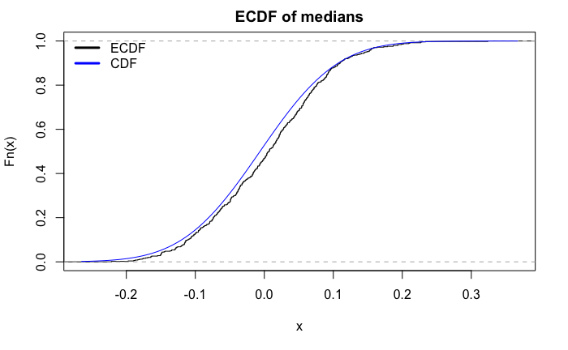

```r
legend(
  "topleft",
  c("ECDF", "CDF"),
  lwd = 3,
  col = c("black", "blue"),
  bty = "n"
)
```

Q_5: Using the simulated sampling distribution from the previous question, create a histogram (on the density scale). Overlay the histogram with a plot of the density function.

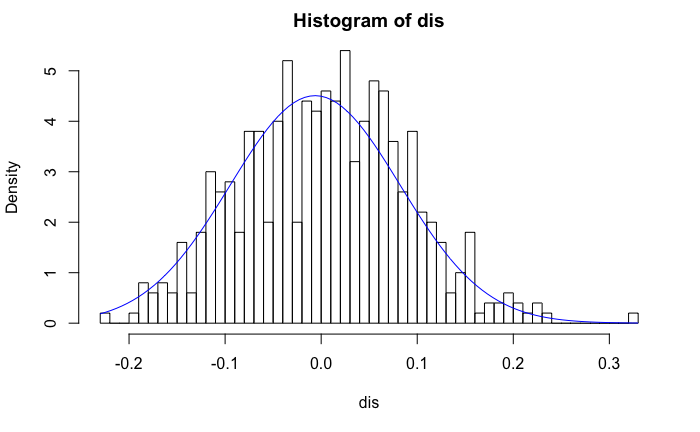

Q_6: One very common way to compare a random sample to a theoretical candidate distribution is the QQ plot. It is created by ploting quantiles of the theoretical distribution on the x-axis and empirical quantiles from the sample on the y-axis.

For the assigment, generate a QQ plot for the simulated data of the median relative to the known sampling distribution of the median.

Does the simulated data agree with the theoretical sampling distribution?

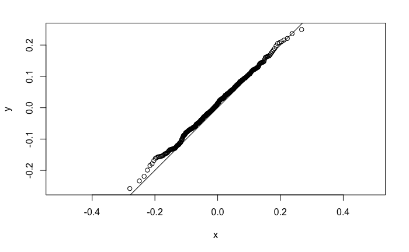

The simulated data seem to agree with the theoretical sampling distribution.

Q_7: Modify the dorder, porder, and qorder functions so that the functions take a new parameter k (for the kt**h order statistic) so that the functions will work for any order statistic and not just the median.

```r
dorder <- function(x, k = 100) {
  n <- 200
  k * choose(n, k) *
  (pnorm(x, 0, 1)) ^ (k - 1) *
  (1 - pnorm(x, 0, 1)) ^ (n - k) *
  dnorm(x, 0, 1)
}
porder <- function(x, k = 100){
  n <- 200
  pbinom(k-1, n, pnorm(x, 0,1), lower.tail = FALSE)
}
qorder <- function(h, k = 100){
  n <- 200
  for(i in seq_along(h)){
    med_dis[i] <- uniroot(function(x, p) porder(x, k)-p, c(-5,5), p = h[i])$root
  }
  med_dis
}
```

Q_8: Generate the QQ plot for simulated data from the sampling distribution of the sample max and the theoretical largest order statistic distribution.

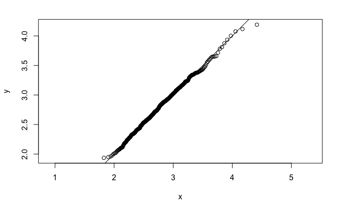

```r
max <- rep(NA, M)   # distribution of medians of the M times of simulation
for(i in 1: M){
  max[i] <- max(rnorm(N))
}
random_sample <- max
q_candidate <- qorder
x <- qorder(points, k = N)
y <- quantile(random_sample, probs = points)
plot(x, y, asp = 1)
abline(0, 1)
```

Q_9: Modify the dorder, porder, and qorder functions so that the functions take new parameters dist and … so that the functions will work for any continuous distribution that has d and p functions defined in R.

```r
`%|%` <- function(a, b) paste0(a,b)
dorder <- function(x, k = 100, dist = norm, ...) {
  pf <- get("p" %|% dist)
  df <- get("d" %|% dist)
  n <- 200
  k * choose(n, k) *
  (pf(x, ...)) ^ (k - 1) *
  (1 - pf(x, ...)) ^ (n - k) *
  df(x, ...)
}
porder <- function(x, k = 100, dist = norm, ...){
  pf <- get("p" %|% dist)

  n <- 200
  pbinom(k-1, n, pf(x,...), lower.tail = FALSE)
}
qorder <- function(h, k = 100){
  pf <- get("p" %|% dist)

  n <- 200
  for(i in seq_along(h)){
    med_dis[i] <- uniroot(function(x, p) pf(x, k, ...)-p, c(-5,5), p = h[i])$root
  }
  med_dis
}
```

Q_10: Use the newly modified functions to plot the probability and density functions for the sample min (N = 200).

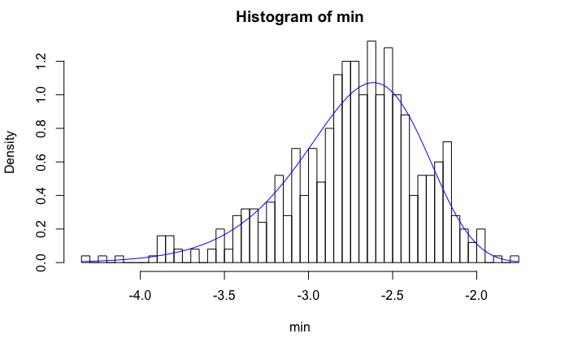

```r
min <- rep(NA, M)   # distribution of min of the M times of simulation
for(i in 1: M){
  min[i] <- min(rnorm(N))
}
hist(min, breaks = 50, freq = FALSE)
curve(dorder(x, 1, dist = "norm"), add = TRUE, col = "blue")
```